# statistics

*solution_03_central_limit_theorem/02_normal/10_bounds_from_twotailarea_v1*

First, draw a sketch. We can label the $C$ axis by adding integer multiples of 150 to 480. We know to shade the the outsides because values far from 480 satisfy the condition $\big|C-480\big|>d$ (regardless of the exact value of $d$). We don’t know exactly where to place the boundaries, but we know the two-tail area is 0.66.

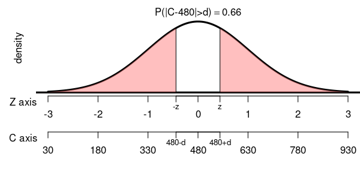

As an intermediate step, let’s find $z$ such that $P(|Z|>z)=0.66$. First, we need to evaluate $P(Z<z)$.

$$\begin{aligned}
P(Z<z) &= \frac{2-P(|Z|>z)}{2} \\ \\
&= \frac{2-0.66}{2} \\ \\
&= 0.67
\end{aligned}$$

You could have also drawn some pictures… we know there is symmetry and all the areas should add to 1.

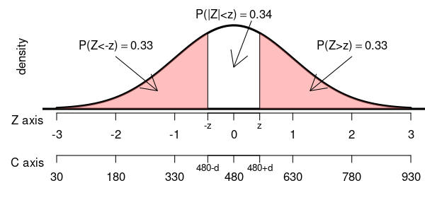

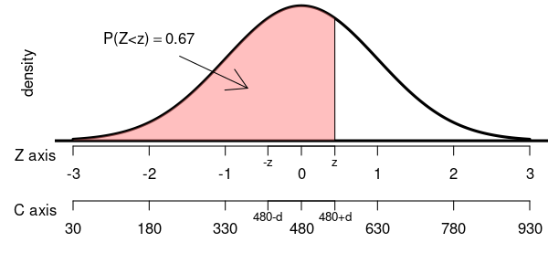

We find $z$ such that $P(Z<z)=0.67$.

By using the $z$ table we can determine $z$.

[output not shown]

Either 0.43 or 0.44 is a good estimation of $z$, and either value will lead you to an acceptable answer. Using other tools, a more accurate value can be found. I will show the work with a more accurate value.
$$z=0.4399$$

We now convert the $z$ score into a $d$ score.
$$\begin{aligned}
d &= z\sigma \\
&= (0.4399)(150) \\
&= 65.99
\end{aligned}$$

We can also visualize this with a spinner.

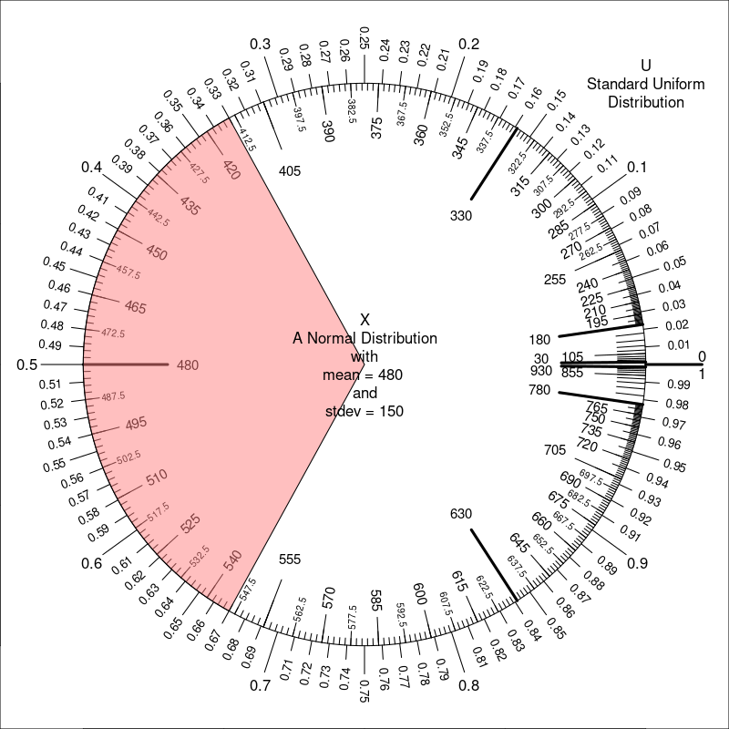

1. We determined $d=65.99$
2. It is easy to find $c_1 = 480-65.99 = 414.01$
3. It is easy to find $c_2 = 480+65.99 = 545.99$